# Tidying data

September 9, 2015

## A funny quote

> "Herein lies the dirty secret about most data scientists' work – it's more data munging than deep learning. The best minds of my generation are deleting commas from log files, and that makes me sad. A Ph.D. is a terrible thing to waste."

http://adage.com/article/digitalnext/dear-madison-avenue-set-data-scientists-free/298676/

## Raw versus processed data

**Raw data** * The original source of the data * Often hard to use for data analyses * Data analysis *includes* processing * Raw data may only need to be processed once

http://en.wikipedia.org/wiki/Raw_data

**Processed data** * Data that is ready for analysis * Processing can include merging, subsetting, transforming, etc. * There may be standards for processing * All steps should be recorded

http://en.wikipedia.org/wiki/Computer_data_processing

## 1,000 genomes example

```r
fileUrl = "ftp://ftp.1000genomes.ebi.ac.uk/vol1/ftp/technical/working/20130606_sample_info/20130606_sample_info.xlsx"
library(downloader)
library(readr)
download(fileUrl,destfile="1000genomes.xlsx")

library(readxl)
# Have to skip one row because
# there is an extra header
kg = read_excel("1000genomes.xlsx",
                    sheet=4,skip=1)
```

## Variable names

```r
head(kg,n=1)
```

```
##    Sample Population Center Platform Total Sequence
## 1 HG00096        GBR  WUGSC ILLUMINA    14714705600
##   Aligned Non Duplicated Coverage Passed QC Center Platform Total Sequence
## 1                            4.94         1  WUGSC ILLUMINA     9580861000
##   % Targets Covered to 20x or greater Passed QC
## 1                            0.851972         1
##   In Final Phase Variant Calling    structure("NA", class = "AsIs")
## 1                              1 NA                              NA
##   structure("NA", class = "AsIs")
## 1                              NA
```

```r
head(kg$`Total Sequence`)
```

```
## [1] 14714705600 30285067857 16332517200 25134554475 42906753668 22115533074
```

## strsplit

```r
strsplit(names(kg)," ")
```

```
## [[1]]
## [1] "Sample"
##
## [[2]]
## [1] "Population"
##
## [[3]]
## [1] "Center"
##
## [[4]]
## [1] "Platform"
##
## [[5]]
## [1] "Total"    "Sequence"
##
## [[6]]
## [1] "Aligned"    "Non"        "Duplicated" "Coverage"
##
## [[7]]
## [1] "Passed" "QC"
##
## [[8]]
## [1] "Center"
##
## [[9]]
## [1] "Platform"
##
## [[10]]
## [1] "Total"    "Sequence"
##
## [[11]]
## [1] "%"       "Targets" "Covered" "to"      "20x"     "or"      "greater"
##
## [[12]]
## [1] "Passed" "QC"
##
## [[13]]
## [1] "In"      "Final"   "Phase"   "Variant" "Calling"
##
## [[14]]
## character(0)
##
## [[15]]
## character(0)
##
## [[16]]
## character(0)
```

```r
strsplit(names(kg)[6]," ")
```

```
## [[1]]
## [1] "Aligned"    "Non"        "Duplicated" "Coverage"
```

## gsub

```r
gsub(" ", "", names(kg))
```

```
##  [1] "Sample"                        "Population"
##  [3] "Center"                        "Platform"
##  [5] "TotalSequence"                 "AlignedNonDuplicatedCoverage"
##  [7] "PassedQC"                      "Center"
##  [9] "Platform"                      "TotalSequence"
## [11] "%TargetsCoveredto20xorgreater" "PassedQC"
## [13] "InFinalPhaseVariantCalling"    ""
## [15] ""                              ""
```

## substr

```r
x = gsub(" ", "", names(kg))
substr(x,1,10)
```

```
##  [1] "Sample"     "Population" "Center"     "Platform"   "TotalSeque"
##  [6] "AlignedNon" "PassedQC"   "Center"     "Platform"   "TotalSeque"
## [11] "%TargetsCo" "PassedQC"   "InFinalPha" ""           ""
## [16] ""
```

## grep

```r
grep("Center",names(kg))
```

```
## [1] 3 8
```

```r
grepl("Center",names(kg))
```

```
##  [1] FALSE FALSE  TRUE FALSE FALSE FALSE FALSE  TRUE FALSE FALSE FALSE
## [12] FALSE FALSE FALSE FALSE FALSE
```

## tolower and toupper

```r
tolower(names(kg))[1:5]
```

```
## [1] "sample"         "population"     "center"         "platform"
## [5] "total sequence"
```

```r
toupper(names(kg))[1:5]
```

```
## [1] "SAMPLE"         "POPULATION"     "CENTER"         "PLATFORM"
## [5] "TOTAL SEQUENCE"
```

## dplyr

[figure not shown]

## Basically this whole part of the lecture from

[figure not shown]

https://stat545-ubc.github.io/block009_dplyr-intro.html

## gapminder example

```r
suppressPackageStartupMessages({library(dplyr)})
gd_url <- "http://www.stat.ubc.ca/~jenny/notOcto/STAT545A/examples/gapminder/data/gapminderDataFiveYear.txt"
gdf <- read.table(file = gd_url,sep="\t",header=T)
head(gdf)
```

```
##       country year      pop continent lifeExp gdpPercap
## 1 Afghanistan 1952  8425333      Asia  28.801  779.4453
## 2 Afghanistan 1957  9240934      Asia  30.332  820.8530
## 3 Afghanistan 1962 10267083      Asia  31.997  853.1007
## 4 Afghanistan 1967 11537966      Asia  34.020  836.1971
## 5 Afghanistan 1972 13079460      Asia  36.088  739.9811
## 6 Afghanistan 1977 14880372      Asia  38.438  786.1134
```

```r
str(gdf)
```

```
## 'data.frame':    1698 obs. of  6 variables:
##  $ country  : Factor w/ 147 levels "Afghanistan",..: 1 1 1 1 1 1 1 1 1 1 ...
##  $ year     : int  1952 1957 1962 1967 1972 1977 1982 1987 1992 1997 ...
##  $ pop      : num  8425333 9240934 10267083 11537966 13079460 ...
##  $ continent: Factor w/ 5 levels "Africa","Americas",..: 3 3 3 3 3 3 3 3 3 3 ...
##  $ lifeExp  : num  28.8 30.3 32 34 36.1 ...
##  $ gdpPercap: num  779 821 853 836 740 ...
```

## tbl_df

```r
gtbl <- tbl_df(gdf)
gtbl
```

```
## Source: local data frame [1,698 x 6]
##
##        country  year      pop continent lifeExp gdpPercap
##         (fctr) (int)    (dbl)    (fctr)   (dbl)     (dbl)
## 1  Afghanistan  1952  8425333      Asia  28.801  779.4453
## 2  Afghanistan  1957  9240934      Asia  30.332  820.8530
## 3  Afghanistan  1962 10267083      Asia  31.997  853.1007
## 4  Afghanistan  1967 11537966      Asia  34.020  836.1971
## 5  Afghanistan  1972 13079460      Asia  36.088  739.9811
## 6  Afghanistan  1977 14880372      Asia  38.438  786.1134
## 7  Afghanistan  1982 12881816      Asia  39.854  978.0114
## 8  Afghanistan  1987 13867957      Asia  40.822  852.3959
## 9  Afghanistan  1992 16317921      Asia  41.674  649.3414
## 10 Afghanistan  1997 22227415      Asia  41.763  635.3414
## ..         ...   ...      ...       ...     ...       ...
```

## glimpse

```r
glimpse(gtbl)
```

```
## Observations: 1,698
## Variables: 6
## $ country   (fctr) Afghanistan, Afghanistan, Afghanistan, Afghanistan,...
## $ year      (int) 1952, 1957, 1962, 1967, 1972, 1977, 1982, 1987, 1992...
## $ pop       (dbl) 8425333, 9240934, 10267083, 11537966, 13079460, 1488...
## $ continent (fctr) Asia, Asia, Asia, Asia, Asia, Asia, Asia, Asia, Asi...
## $ lifeExp   (dbl) 28.801, 30.332, 31.997, 34.020, 36.088, 38.438, 39.8...
## $ gdpPercap (dbl) 779.4453, 820.8530, 853.1007, 836.1971, 739.9811, 78...
```

## filter

```r
filter(gtbl, lifeExp < 29)
```

```
## Source: local data frame [2 x 6]
##
##       country  year     pop continent lifeExp gdpPercap
##        (fctr) (int)   (dbl)    (fctr)   (dbl)     (dbl)
## 1 Afghanistan  1952 8425333      Asia  28.801  779.4453
## 2      Rwanda  1992 7290203    Africa  23.599  737.0686
```

```r
filter(gtbl, country == "Rwanda")
```

```
## Source: local data frame [12 x 6]
##
##    country  year     pop continent lifeExp gdpPercap
##     (fctr) (int)   (dbl)    (fctr)   (dbl)     (dbl)
## 1   Rwanda  1952 2534927    Africa  40.000  493.3239
## 2   Rwanda  1957 2822082    Africa  41.500  540.2894
## 3   Rwanda  1962 3051242    Africa  43.000  597.4731
## 4   Rwanda  1967 3451079    Africa  44.100  510.9637
## 5   Rwanda  1972 3992121    Africa  44.600  590.5807
## 6   Rwanda  1977 4657072    Africa  45.000  670.0806
## 7   Rwanda  1982 5507565    Africa  46.218  881.5706
## 8   Rwanda  1987 6349365    Africa  44.020  847.9912
## 9   Rwanda  1992 7290203    Africa  23.599  737.0686
## 10  Rwanda  1997 7212583    Africa  36.087  589.9445
## 11  Rwanda  2002 7852401    Africa  43.413  785.6538
## 12  Rwanda  2007 8860588    Africa  46.242  863.0885
```

## select

```r
select(gtbl,country,pop,continent)
```

```
## Source: local data frame [1,698 x 3]
##
##        country      pop continent
##         (fctr)    (dbl)    (fctr)
## 1  Afghanistan  8425333      Asia
## 2  Afghanistan  9240934      Asia
## 3  Afghanistan 10267083      Asia
## 4  Afghanistan 11537966      Asia
## 5  Afghanistan 13079460      Asia
## 6  Afghanistan 14880372      Asia
## 7  Afghanistan 12881816      Asia
## 8  Afghanistan 13867957      Asia
## 9  Afghanistan 16317921      Asia
## 10 Afghanistan 22227415      Asia
## ..         ...      ...       ...
```

## arrange

```r
arrange(gtbl,pop)
```

```
## Source: local data frame [1,698 x 6]
##
##                  country  year   pop continent lifeExp gdpPercap
##                   (fctr) (int) (dbl)    (fctr)   (dbl)     (dbl)
## 1  Sao Tome and Principe  1952 60011    Africa  46.471  879.5836
## 2  Sao Tome and Principe  1957 61325    Africa  48.945  860.7369
## 3               Djibouti  1952 63149    Africa  34.812 2669.5295
## 4  Sao Tome and Principe  1962 65345    Africa  51.893 1071.5511
## 5  Sao Tome and Principe  1967 70787    Africa  54.425 1384.8406
## 6               Djibouti  1957 71851    Africa  37.328 2864.9691
## 7  Sao Tome and Principe  1972 76595    Africa  56.480 1532.9853
## 8  Sao Tome and Principe  1977 86796    Africa  58.550 1737.5617
## 9               Djibouti  1962 89898    Africa  39.693 3020.9893
## 10 Sao Tome and Principe  1982 98593    Africa  60.351 1890.2181
## ..                   ...   ...   ...       ...     ...       ...
```

## desc

```r
arrange(gtbl,desc(pop))
```

```
## Source: local data frame [1,698 x 6]
##
##    country  year        pop continent  lifeExp gdpPercap
##     (fctr) (int)      (dbl)    (fctr)    (dbl)     (dbl)
## 1    China  2007 1318683096      Asia 72.96100 4959.1149
## 2    China  2002 1280400000      Asia 72.02800 3119.2809
## 3    China  1997 1230075000      Asia 70.42600 2289.2341
## 4    China  1992 1164970000      Asia 68.69000 1655.7842
## 5    India  2007 1110396331      Asia 64.69800 2452.2104
## 6    China  1987 1084035000      Asia 67.27400 1378.9040
## 7    India  2002 1034172547      Asia 62.87900 1746.7695
## 8    China  1982 1000281000      Asia 65.52500  962.4214
## 9    India  1997  959000000      Asia 61.76500 1458.8174
## 10   China  1977  943455000      Asia 63.96736  741.2375
## ..     ...   ...        ...       ...      ...       ...
```

## mutate

```r
gtbl = mutate(gtbl,newVar = (lifeExp / gdpPercap))
select(gtbl,lifeExp,gdpPercap,newVar)
```

```
## Source: local data frame [1,698 x 3]
##
##    lifeExp gdpPercap     newVar
##      (dbl)     (dbl)      (dbl)
## 1   28.801  779.4453 0.03695064
## 2   30.332  820.8530 0.03695180
## 3   31.997  853.1007 0.03750671
## 4   34.020  836.1971 0.04068419
## 5   36.088  739.9811 0.04876881
## 6   38.438  786.1134 0.04889626
## 7   39.854  978.0114 0.04075003
## 8   40.822  852.3959 0.04789089
## 9   41.674  649.3414 0.06417887
## 10  41.763  635.3414 0.06573317
## ..     ...       ...        ...
```

## distinct

```r
distinct(gtbl)
```

```
## Source: local data frame [1,698 x 7]
##
##        country  year      pop continent lifeExp gdpPercap     newVar
##         (fctr) (int)    (dbl)    (fctr)   (dbl)     (dbl)      (dbl)
## 1  Afghanistan  1952  8425333      Asia  28.801  779.4453 0.03695064
## 2  Afghanistan  1957  9240934      Asia  30.332  820.8530 0.03695180
## 3  Afghanistan  1962 10267083      Asia  31.997  853.1007 0.03750671
## 4  Afghanistan  1967 11537966      Asia  34.020  836.1971 0.04068419
## 5  Afghanistan  1972 13079460      Asia  36.088  739.9811 0.04876881
## 6  Afghanistan  1977 14880372      Asia  38.438  786.1134 0.04889626
## 7  Afghanistan  1982 12881816      Asia  39.854  978.0114 0.04075003
## 8  Afghanistan  1987 13867957      Asia  40.822  852.3959 0.04789089
## 9  Afghanistan  1992 16317921      Asia  41.674  649.3414 0.06417887
## 10 Afghanistan  1997 22227415      Asia  41.763  635.3414 0.06573317
## ..         ...   ...      ...       ...     ...       ...        ...
```

## Key principle

[figure not shown]

https://twitter.com/elliemcdonagh/status/469184554549248000

## Key principle

[figure not shown]

https://twitter.com/elliemcdonagh/status/469184554549248000

## sample_n / sample_frac

```r
sample_n(gtbl,3)
```

```
## Source: local data frame [3 x 7]
##
##              country  year      pop continent lifeExp gdpPercap     newVar
##               (fctr) (int)    (dbl)    (fctr)   (dbl)     (dbl)      (dbl)
## 1 West Bank and Gaza  1962  1133134      Asia  48.127 2198.9563 0.02188629
## 2              Syria  2002 17155814      Asia  73.053 4090.9253 0.01785733
## 3       Sierra Leone  1997  4578212    Africa  39.897  574.6482 0.06942857
```

## pipes

[figure not shown]

http://cran.r-project.org/web/packages/magrittr/index.html

## What does pipe do?

```r
gtbl %>% head
```

```
## Source: local data frame [6 x 7]
##
##       country  year      pop continent lifeExp gdpPercap     newVar
##        (fctr) (int)    (dbl)    (fctr)   (dbl)     (dbl)      (dbl)
## 1 Afghanistan  1952  8425333      Asia  28.801  779.4453 0.03695064
## 2 Afghanistan  1957  9240934      Asia  30.332  820.8530 0.03695180
## 3 Afghanistan  1962 10267083      Asia  31.997  853.1007 0.03750671
## 4 Afghanistan  1967 11537966      Asia  34.020  836.1971 0.04068419
## 5 Afghanistan  1972 13079460      Asia  36.088  739.9811 0.04876881
## 6 Afghanistan  1977 14880372      Asia  38.438  786.1134 0.04889626
```

## What does pipe do?

```r
gtbl %>% head(3)
```

```
## Source: local data frame [3 x 7]
##
##       country  year      pop continent lifeExp gdpPercap     newVar
##        (fctr) (int)    (dbl)    (fctr)   (dbl)     (dbl)      (dbl)
## 1 Afghanistan  1952  8425333      Asia  28.801  779.4453 0.03695064
## 2 Afghanistan  1957  9240934      Asia  30.332  820.8530 0.03695180
## 3 Afghanistan  1962 10267083      Asia  31.997  853.1007 0.03750671
```

## Example

Show me a random sample of the data for Asian countries with life expectancy < 65.

```r
gtbl1 = gtbl[gtbl$continent=="Asia",]
gtbl2 = gtbl1[gtbl1$lifeExp < 65,]
gtbl3 = gtbl2[sample(1:dim(gtbl2)[1],size=10),]
gtbl3
```

```
## Source: local data frame [10 x 7]
##
##         country  year       pop continent lifeExp   gdpPercap       newVar
##          (fctr) (int)     (dbl)    (fctr)   (dbl)       (dbl)        (dbl)
## 1         Syria  1982   9410494      Asia  64.590   3761.8377 0.0171697997
## 2       Bahrain  1962    171863      Asia  56.923  12753.2751 0.0044634025
## 3         Nepal  1962  10332057      Asia  39.393    652.3969 0.0603819584
## 4          Oman  1967    714775      Asia  46.988   4720.9427 0.0099530969
## 5        Kuwait  1957    212846      Asia  58.033 113523.1329 0.0005111998
## 6      Pakistan  1987 105186881      Asia  58.245   1704.6866 0.0341675711
## 7         India  1952 372000000      Asia  37.373    546.5657 0.0683778668
## 8  Saudi Arabia  1952   4005677      Asia  39.875   6459.5548 0.0061730260
## 9         Nepal  1952   9182536      Asia  36.157    545.8657 0.0662379015
## 10    Singapore  1952   1127000      Asia  60.396   2315.1382 0.0260874272
```

## w/pipes

```r
gtbl %>% filter(continent == "Asia") %>%
         filter(lifeExp < 65) %>%
         sample_n(10)
```

```
## Source: local data frame [10 x 7]
##
##         country  year       pop continent lifeExp  gdpPercap      newVar
##          (fctr) (int)     (dbl)    (fctr)   (dbl)      (dbl)       (dbl)
## 1       Myanmar  1952  20092996      Asia  36.319   331.0000 0.109725076
## 2      Pakistan  1982  91462088      Asia  56.158  1443.4298 0.038905944
## 3         India  1967 506000000      Asia  47.193   700.7706 0.067344434
## 4       Bahrain  1962    171863      Asia  56.923 12753.2751 0.004463402
## 5         India  1957 409000000      Asia  40.249   590.0620 0.068211477
## 6     Sri Lanka  1952   7982342      Asia  57.593  1083.5320 0.053153020
## 7  Saudi Arabia  1952   4005677      Asia  39.875  6459.5548 0.006173026
## 8     Indonesia  1992 184816000      Asia  62.681  2383.1409 0.026301844
## 9         Nepal  1987  17917180      Asia  52.537   775.6325 0.067734402
## 10      Bahrain  1967    202182      Asia  59.923 14804.6727 0.004047573
```

## Another example

What is the average life expectancy by continent?

```r
gtbl %>% group_by(continent) %>%
         summarize(aveLife = mean(lifeExp))
```

```
## Source: local data frame [5 x 2]
##
##   continent  aveLife
##      (fctr)    (dbl)
## 1    Africa 48.87362
## 2  Americas 64.65874
## 3      Asia 60.06490
## 4    Europe 71.90369
## 5   Oceania 74.32621
```

## The old-fashioned way

```r
tapply(gtbl$lifeExp,gtbl$continent,mean)
```

```
##   Africa Americas     Asia   Europe  Oceania
## 48.87362 64.65874 60.06490 71.90369 74.32621
```

```r
sapply(gtbl$continent,function(x){substr(x,1,3)})[1:10]
```

```
##  [1] "Asi" "Asi" "Asi" "Asi" "Asi" "Asi" "Asi" "Asi" "Asi" "Asi"
```

```r
splitlife= split(gtbl$lifeExp,gtbl$continent)
lapply(splitlife,mean)
```

```
## $Africa
## [1] 48.87362
##
## $Americas
## [1] 64.65874
##
## $Asia
## [1] 60.0649
##
## $Europe
## [1] 71.90369
##
## $Oceania
## [1] 74.32621
```

## Common summarize options

[figure not shown]

## Passing to another argument

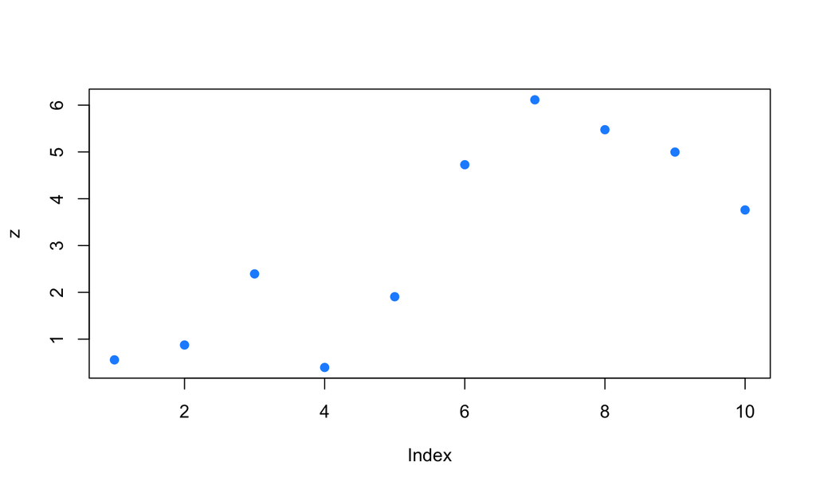

```r
x = rep(c(1,5),each=5)
z = x %>% rnorm(10,mean=.)
plot(z,pch=19,col="dodgerblue")
```

## Gotta be in the "Hadley mindset"

```r
sesmat = dst %>% group_by(coursera_user_id) %>% arrange(coursera_user_id,session_date) %>%
  summarize(first_session = min(session_num),
            ses1 = c(1) %in% (session_num - first_session + 1),
            ses2 = c(2) %in% (session_num - first_session + 1),
            ses3 = c(3) %in% (session_num - first_session + 1),
            ses4 = c(4) %in% (session_num - first_session + 1),
            ses5 = c(5) %in% (session_num - first_session + 1),
            ses6 = c(6) %in% (session_num - first_session + 1),
            ses7 = c(7) %in% (session_num - first_session + 1),
            ses8 = c(8) %in% (session_num - first_session + 1),
            ses9 = c(9) %in% (session_num - first_session + 1),
            ses10 = c(10) %in% (session_num - first_session + 1),
            ses11 = c(11) %in% (session_num - first_session + 1),
            ses12 = c(12) %in% (session_num - first_session + 1))
```

## Merging data sets

The worst and most common task.

```r
library(readxl)
kg_s4 = read_excel("1000genomes.xlsx",
                    sheet=4,skip=1)

kg_s1 = read_excel("1000genomes.xlsx",
                    sheet=1)
head(kg_s4,n=1)
```

```
## Source: local data frame [1 x 16]
##
##    Sample Population Center Platform Total Sequence
##     (chr)      (chr)  (chr)    (chr)          (dbl)
## 1 HG00096        GBR  WUGSC ILLUMINA    14714705600
## Variables not shown: Aligned Non Duplicated Coverage (dbl), Passed QC
##   (dbl), Center (chr), Platform (chr), Total Sequence (dbl), % Targets
##   Covered to 20x or greater (dbl), Passed QC (dbl), In Final Phase Variant
##   Calling (dbl), (dbl), structure("NA", class = "AsIs") (dbl),
##   structure("NA", class = "AsIs") (dbl)
```

```r
head(kg_s1,n=1)
```

```
## Source: local data frame [1 x 15]
##
##    Sample Family ID Population          Population Description Gender
##     (chr)     (chr)      (chr)                           (chr)  (chr)
## 1 HG00096   HG00096        GBR British in England and Scotland   male
## Variables not shown: Relationship (chr), Unexpected Parent/Child (chr),
##   Non Paternity (dbl), Siblings (chr), Grandparents (dbl), Avuncular
##   (dbl), Half Siblings (dbl), Unknown Second Order (chr), Third Order
##   (dbl), Other Comments (dbl)
```

## names

```r
names(kg_s1)
```

```
##  [1] "Sample"                   "Family ID"
##  [3] "Population"               "Population Description"
##  [5] "Gender"                   "Relationship"
##  [7] "Unexpected Parent/Child " "Non Paternity"
##  [9] "Siblings"                 "Grandparents"
## [11] "Avuncular"                "Half Siblings"
## [13] "Unknown Second Order"     "Third Order"
## [15] "Other Comments"
```

```r
names(kg_s4)
```

```
##  [1] "Sample"
##  [2] "Population"
##  [3] "Center"
##  [4] "Platform"
##  [5] "Total Sequence"
##  [6] "Aligned Non Duplicated Coverage"
##  [7] "Passed QC"
##  [8] "Center"
##  [9] "Platform"
## [10] "Total Sequence"
## [11] "% Targets Covered to 20x or greater"
## [12] "Passed QC"
## [13] "In Final Phase Variant Calling"
## [14] ""
## [15] ""
## [16] ""
```

## merge

```r
kg_new = merge(kg_s4,kg_s1)
dim(kg_new)
```

```
## [1] 3500   29
```

```r
names(kg_new)
```

```
##  [1] "Sample"
##  [2] "Population"
##  [3] "Center"
##  [4] "Platform"
##  [5] "Total Sequence"
##  [6] "Aligned Non Duplicated Coverage"
##  [7] "Passed QC"
##  [8] "Center"
##  [9] "Platform"
## [10] "Total Sequence"
## [11] "% Targets Covered to 20x or greater"
## [12] "Passed QC"
## [13] "In Final Phase Variant Calling"
## [14] "Var.14"
## [15] "Var.15"
## [16] "Var.16"
## [17] "Family ID"
## [18] "Population Description"
## [19] "Gender"
## [20] "Relationship"
## [21] "Unexpected Parent/Child "
## [22] "Non Paternity"
## [23] "Siblings"
## [24] "Grandparents"
## [25] "Avuncular"
## [26] "Half Siblings"
## [27] "Unknown Second Order"
## [28] "Third Order"
## [29] "Other Comments"
```

## More on types of joins

[figure not shown]

https://stat545-ubc.github.io/bit001_dplyr-cheatsheet.html

## Superhero example

```r
superheroes <-
  c("    name, alignment, gender,         publisher",
    " Magneto,       bad,   male,            Marvel",
    "   Storm,      good, female,            Marvel",
    "Mystique,       bad, female,            Marvel",
    "  Batman,      good,   male,                DC",
    "   Joker,       bad,   male,                DC",
    "Catwoman,       bad, female,                DC",
    " Hellboy,      good,   male, Dark Horse Comics")

superheroes <- read.csv(text = superheroes, strip.white = TRUE)
```

https://stat545-ubc.github.io/bit001_dplyr-cheatsheet.html

## Superheroes example

```r
publishers <-
  c("publisher, yr_founded",
    "       DC,       1934",
    "   Marvel,       1939",
    "    Image,       1992")
publishers <- read.csv(text = publishers, strip.white = TRUE)
```

## Inner join

```r
ijsp = inner_join(superheroes, publishers)
ijsp
```

```
##       name alignment gender publisher yr_founded
## 1  Magneto       bad   male    Marvel       1939
## 2    Storm      good female    Marvel       1939
## 3 Mystique       bad female    Marvel       1939
## 4   Batman      good   male        DC       1934
## 5    Joker       bad   male        DC       1934
## 6 Catwoman       bad female        DC       1934
```

## Comparison

[figure not shown]

## Left join

```r
ljsp = left_join(superheroes, publishers)
ljsp
```

```
##       name alignment gender         publisher yr_founded
## 1  Magneto       bad   male            Marvel       1939
## 2    Storm      good female            Marvel       1939
## 3 Mystique       bad female            Marvel       1939
## 4   Batman      good   male                DC       1934
## 5    Joker       bad   male                DC       1934
## 6 Catwoman       bad female                DC       1934
## 7  Hellboy      good   male Dark Horse Comics         NA
```

## Comparison

[figure not shown]

## Outer join (using merge)

```r
ojsp = merge(superheroes, publishers, all = TRUE)
ojsp
```

```
##           publisher     name alignment gender yr_founded
## 1 Dark Horse Comics  Hellboy      good   male         NA
## 2                DC   Batman      good   male       1934
## 3                DC    Joker       bad   male       1934
## 4                DC Catwoman       bad female       1934
## 5            Marvel  Magneto       bad   male       1939
## 6            Marvel    Storm      good female       1939
## 7            Marvel Mystique       bad female       1939
## 8             Image     <NA>      <NA>   <NA>       1992
```

## Merging different names

```r
superheroes = mutate(superheroes,
                jefflikes = (publisher=="Marvel"))
publishers = mutate(publishers,
                    jeff = (publisher == "Marvel"))
ij2 = inner_join(superheroes,publishers)
ij2
```

```
##       name alignment gender publisher jefflikes yr_founded  jeff
## 1  Magneto       bad   male    Marvel      TRUE       1939  TRUE
## 2    Storm      good female    Marvel      TRUE       1939  TRUE
## 3 Mystique       bad female    Marvel      TRUE       1939  TRUE
## 4   Batman      good   male        DC     FALSE       1934 FALSE
## 5    Joker       bad   male        DC     FALSE       1934 FALSE
## 6 Catwoman       bad female        DC     FALSE       1934 FALSE
```

## Merging different names

```r
ij2 = inner_join(superheroes,publishers,
                    by=c("publisher"="publisher",
                            "jefflikes"="jeff"))
ij2
```

```
##       name alignment gender publisher jefflikes yr_founded
## 1  Magneto       bad   male    Marvel      TRUE       1939
## 2    Storm      good female    Marvel      TRUE       1939
## 3 Mystique       bad female    Marvel      TRUE       1939
## 4   Batman      good   male        DC     FALSE       1934
## 5    Joker       bad   male        DC     FALSE       1934
## 6 Catwoman       bad female        DC     FALSE       1934
```

## Matching variables

```r
match(superheroes$publisher,publishers$publisher)
```

```
## [1]  2  2  2  1  1  1 NA
```

```r
match(publishers$publisher,superheroes$publisher)
```

```
## [1]  4  1 NA
```

```r
matchIndex = match(superheroes$publisher,publishers$publisher)
publishers[matchIndex,]
```

```
##     publisher yr_founded  jeff
## 2      Marvel       1939  TRUE
## 2.1    Marvel       1939  TRUE
## 2.2    Marvel       1939  TRUE
## 1          DC       1934 FALSE
## 1.1        DC       1934 FALSE
## 1.2        DC       1934 FALSE
## NA       <NA>         NA    NA
```

## Regular expressions

- Regular expressions can be thought of as a combination of literals and *metacharacters*
- To draw an analogy with natural language, think of literal text forming the words of this language, and the metacharacters defining its grammar
- Regular expressions have a rich set of metacharacters

## Regular expressions

Find all "BGI"

```r
library(readxl)
kg = read_excel("1000genomes.xlsx",sheet=4,skip=1)
table(kg$Center)
```

```
##
##            BCM        BCM,BGI         BCM,BI         BCM,SC      BCM,WUGSC
##            159              1              8              6              3
##            BGI             BI       BI,MPIMG       Illumina       ILLUMINA
##            626            578              1              1            104
## ILLUMINA,WUGSC          MPIMG             SC          WUGSC
##              2             95            739            365
```

## grep

```r
grep("BCM",kg$Center)[1:10]
```

```
##  [1]   2   4   9  33  34  35  86  87 174 175
```

```r
grepl("BCM",kg$Center)[1:10]
```

```
##  [1] FALSE  TRUE FALSE  TRUE FALSE FALSE FALSE FALSE  TRUE FALSE
```

## stringr

```r
library(stringr)
str_detect(kg$Center,"BCM")[1:40]
```

```
##  [1] FALSE  TRUE FALSE  TRUE FALSE FALSE FALSE FALSE  TRUE FALSE FALSE
## [12] FALSE FALSE FALSE FALSE FALSE FALSE FALSE FALSE FALSE FALSE FALSE
## [23] FALSE FALSE FALSE FALSE FALSE FALSE FALSE FALSE FALSE FALSE  TRUE
## [34]  TRUE  TRUE FALSE FALSE FALSE FALSE FALSE
```

```r
str_subset(kg$Center,"BCM")[64:73]
```

```
##  [1] "BCM"       "BCM"       "BCM,BGI"   "BCM,SC"    "BCM"
##  [6] "BCM,BI"    "BCM,BI"    "BCM,WUGSC" "BCM,BI"    "BCM,SC"
```

https://github.com/hadley/stringr/blob/master/vignettes/stringr.Rmd https://cran.r-project.org/web/packages/stringr/vignettes/stringr.html

## A few string operations I use a lot

```r
str_trim("Jeff      ")
```

```
## [1] "Jeff"
```

```r
paste0("Jeffrey","Leek")
```

```
## [1] "JeffreyLeek"
```

```r
nchar("Jeffrey Leek")
```

```
## [1] 12
```

## Literals: nuclear

[figure not shown]

## Literals: Obama

[figure not shown]

## But text is more complicated

We need a way to express - whitespace word boundaries - sets of literals - the beginning and end of a line - alternatives (“war” or “peace”)

## Beginning of line with ^

```r
x = c("i think we all rule for participating",
"i think i have been outed",
"i think this will be quite fun actually",
"it will be fun, i think")

str_detect(x, "^i think")
```

```
## [1]  TRUE  TRUE  TRUE FALSE
```

## End of line with $

```r
x = c("well they had something this morning",
"then had to catch a tram home in the morning",
"dog obedience school in the morning",
"this morning I'll go for a run")

str_detect(x, "morning$")
```

```
## [1]  TRUE  TRUE  TRUE FALSE
```

## Character lists with []

```r
x = c('Name the worst thing about Bush!',
'I saw a green bush',
'BBQ and bushwalking at Molonglo Gorge',
'BUSH!!')

str_detect(x,"[Bb][Uu][Ss][Hh]")
```

```
## [1] TRUE TRUE TRUE TRUE
```

## Sets of letters or numbers

```r
x = c('7th inning stretch',
'2nd half soon to begin. OSU did just win.',
'3am - cant sleep - too hot still.. :(',
'5ft 7 sent from heaven')

str_detect(x,"^[0-9][a-zA-Z]")
```

```
## [1] TRUE TRUE TRUE TRUE
```

## Negative classes

```r
x = c('are you there?',
'2nd half soon to begin. OSU did just win.',
'6 and 9',
'dont worry... we all die anyway!')

str_detect(x,"[^?.]$")
```

```
## [1] FALSE FALSE  TRUE  TRUE
```

## . means anything

```r
x = c('its stupid the post 9-11 rules',
'NetBios: scanning ip 203.169.114.66',
'Front Door 9:11:46 AM',
'Sings: 0118999881999119725...3 !')

str_detect(x,"9.11")
```

```
## [1] TRUE TRUE TRUE TRUE
```

```r
x = c('Not a whole lot of hurricanes.',
'We do have floods nearly every day',
'hurricanes swirl in the other direction',
'coldfire is STRAIGHT!')

str_detect(x,"flood|earthquake|hurricane|coldfire")
```

```
## [1] TRUE TRUE TRUE TRUE
```

## More Metacharacters: ( and )

Subexpressions are often contained in parentheses to constrain the alternatives

```markdown
^([Gg]ood|[Bb]ad)
```

will match the lines

```markdown
bad habbit
bad coordination today
good, becuase there is nothing worse than a man in kinky underwear
Badcop, its because people want to use drugs
Good Monday Holiday
Good riddance to Limey
```

## More Metacharacters: ?

The question mark indicates that the indicated expression is optional

```markdown
[Gg]eorge( [Ww]\.)? [Bb]ush
```

will match the lines

```markdown
i bet i can spell better than you and george bush combined
BBC reported that President George W. Bush claimed God told him to invade I
a bird in the hand is worth two george bushes
```

## One thing to note…

In the following

```markdown
[Gg]eorge( [Ww]\.)? [Bb]ush
```

we wanted to match a “.” as a literal period; to do that, we had to “escape” the metacharacter, preceding it with a backslash In general, we have to do this for any metacharacter we want to include in our match

## More metacharacters: * and +

The * and + signs are metacharacters used to indicate repetition; * means “any number, including none, of the item” and + means “at least one of the item”

```markdown
(.*)
```

will match the lines

```markdown
anyone wanna chat? (24, m, germany)
hello, 20.m here... ( east area + drives + webcam )
(he means older men)
()
```

## More metacharacters: * and +

The * and + signs are metacharacters used to indicate repetition; * means “any number, including none, of the item” and + means “at least one of the item”

```markdown
[0-9]+ (.*)[0-9]+
```

will match the lines

```markdown
working as MP here 720 MP battallion, 42nd birgade
so say 2 or 3 years at colleage and 4 at uni makes us 23 when and if we fin
it went down on several occasions for like, 3 or 4 *days*
Mmmm its time 4 me 2 go 2 bed
```

## More metacharacters: { and }

{ and } are referred to as interval quantifiers; the let us specify the minimum and maximum number of matches of an expression

```markdown
[Bb]ush( +[^ ]+ +){1,5} debate
```

will match the lines

```markdown
Bush has historically won all major debates he’s done.
in my view, Bush doesn’t need these debates..
bush doesn’t need the debates? maybe you are right
That’s what Bush supporters are doing about the debate.
Felix, I don’t disagree that Bush was poorly prepared for the debate.
indeed, but still, Bush should have taken the debate more seriously.
Keep repeating that Bush smirked and scowled during the debate
```

## More metacharacters: ( and ) revisited

So the expression

```markdown
+([a-zA-Z]+) +\1 +
```

will match the lines

```markdown
time for bed, night night twitter!
blah blah blah blah
my tattoo is so so itchy today
i was standing all all alone against the world outside...
hi anybody anybody at home
estudiando css css css css.... que desastritooooo
```

## detecting phone numbers

```r
x = c('206-555-1122','206-332','4545','test')

phone = "([2-9][0-9]{2})[- .]([0-9]{3})[- .]([0-9]{4})"

str_detect(x,phone)
```

```
## [1]  TRUE FALSE FALSE FALSE
```

## Can this get ridiculous?

*You bet!*

[figure not shown]

https://regex.alf.nu/

## Like really ridiculous

[figure not shown]

https://xkcd.com/1313/

## A nice tutorial

[figure not shown]

http://stat545-ubc.github.io/block022_regular-expression.html

## Important points about text in data sets

- Names of variables should be
- All lower case when possible
- Descriptive (Diagnosis versus Dx)
- Not duplicated
- Not have underscores or dots or white spaces
- Variables with character values
- Should usually be made into factor variables (depends on application)
- Should be descriptive (use TRUE/FALSE instead of 0/1 and Male/Female versus 0/1 or M/F)

## Starting simple

```r
d1 = date()
d1
```

```
## [1] "Wed Sep 16 13:16:22 2015"
```

```r
class(d1)
```

```
## [1] "character"
```

## Date class

```r
d2 = Sys.Date()
d2
```

```
## [1] "2015-09-16"
```

```r
class(d2)
```

```
## [1] "Date"
```

## Formatting dates

`%d` = day as number (0-31), `%a` = abbreviated weekday,`%A` = unabbreviated weekday, `%m` = month (00-12), `%b` = abbreviated month, `%B` = unabbrevidated month, `%y` = 2 digit year, `%Y` = four digit year

```r
format(d2,"%a %b %d")
```

```
## [1] "Wed Sep 16"
```

## Creating dates

```r
x = c("1jan1960", "2jan1960", "31mar1960", "30jul1960"); z = as.Date(x, "%d%b%Y")
z
```

```
## [1] "1960-01-01" "1960-01-02" "1960-03-31" "1960-07-30"
```

```r
z[1] - z[2]
```

```
## Time difference of -1 days
```

```r
as.numeric(z[1]-z[2])
```

```
## [1] -1
```

## Converting to Julian

```r
weekdays(d2)
```

```
## [1] "Wednesday"
```

```r
months(d2)
```

```
## [1] "September"
```

```r
julian(d2)
```

```
## [1] 16694
## attr(,"origin")
## [1] "1970-01-01"
```

## Lubridate

```r
library(lubridate); ymd("20140108")
```

```
## [1] "2014-01-08 UTC"
```

```r
mdy("08/04/2013")
```

```
## [1] "2013-08-04 UTC"
```

```r
dmy("03-04-2013")
```

```
## [1] "2013-04-03 UTC"
```

http://www.r-statistics.com/2012/03/do-more-with-dates-and-times-in-r-with-lubridate-1-1-0/

## Dealing with times

```r
ymd_hms("2011-08-03 10:15:03")
```

```
## [1] "2011-08-03 10:15:03 UTC"
```

```r
ymd_hms("2011-08-03 10:15:03",tz="Pacific/Auckland")
```

```
## [1] "2011-08-03 10:15:03 NZST"
```

```r
?Sys.timezone
```

http://www.r-statistics.com/2012/03/do-more-with-dates-and-times-in-r-with-lubridate-1-1-0/

## Some functions have slightly different syntax

```r
x = dmy(c("1jan2013", "2jan2013", "31mar2013", "30jul2013"))
wday(x[1])
```

```
## [1] 3
```

```r
wday(x[1],label=TRUE)
```

```
## [1] Tues
## Levels: Sun < Mon < Tues < Wed < Thurs < Fri < Sat
```

## Notes and further resources

- More information in this nice lubridate tutorial http://www.r-statistics.com/2012/03/do-more-with-dates-and-times-in-r-with-lubridate-1-1-0/
- The lubridate vignette is the same content http://cran.r-project.org/web/packages/lubridate/vignettes/lubridate.html
- Ultimately you want your dates and times as class "Date" or the classes "POSIXct", "POSIXlt". For more information type `?POSIXlt`

## Lab time

- [dplyr](https://github.com/SISBID/Module1/blob/gh-pages/labs/dplyr-lab.Rmd)
- [regex](https://github.com/SISBID/Module1/blob/gh-pages/labs/regex-lab.Rmd)
- [merging](https://github.com/SISBID/Module1/blob/gh-pages/labs/merging-lab.Rmd)
- [final](https://github.com/SISBID/Module1/blob/gh-pages/labs/final-lab.Rmd)